# Assignment 2: Spatial Analysis and Visualization

Healthcare Access and Equity in Pennsylvania

Author

Zhe Fang

Published

December 1, 2025

## Assignment Overview

**Learning Objectives:** - Apply spatial operations to answer policy-relevant research questions - Integrate census demographic data with spatial analysis - Create publication-quality visualizations and maps - Work with spatial data from multiple sources - Communicate findings effectively for policy audiences

## Part 1: Healthcare Access for Vulnerable Populations

### Research Question

**Which Pennsylvania counties have the highest proportion of vulnerable populations (elderly + low-income) living far from hospitals?**

Your analysis should identify counties that should be priorities for healthcare investment and policy intervention.

### Required Analysis Steps

Complete the following analysis, documenting each step with code and brief explanations:

#### Step 1: Data Collection (5 points)

Load the required spatial data: - Pennsylvania county boundaries - Pennsylvania hospitals (from lecture data) - Pennsylvania census tracts

**Your Task:**

```r
# Load required packages
library(tidyverse)
library(sf)
library(tigris)
library(tidycensus)
options(tigris_use_cache = TRUE, tigris_class = "sf")

data_dir <- "D:/pen/MUSA5080PublicPolicyAnalytics/assignment2/week-04_data"

# Load spatial data
# 1) Pennsylvania county boundaries
counties_path <- file.path(data_dir, "Pennsylvania_County_Boundaries.shp")
pa_counties <- st_read(counties_path, quiet = TRUE) |> st_transform(4326)

# 2) Pennsylvania hospitals
hospitals_path <- file.path(data_dir, "hospitals.geojson")
hospitals <- st_read(hospitals_path, quiet = TRUE) |> st_transform(4326)

# 3) Pennsylvania census tracts
acs_year <- 2022
pa_tracts <- tigris::tracts(state = "PA", year = acs_year, cb = TRUE) |> st_transform(4326)

# Check that all data loaded correctly
n_hospitals <- nrow(hospitals)
n_tracts <- nrow(pa_tracts)

crs_county <- st_crs(pa_counties)$input
crs_hosp <- st_crs(hospitals)$input
crs_tract <- st_crs(pa_tracts)$input

list(
  hospitals_n = n_hospitals,
  tracts_n = n_tracts,
  crs = list(
    counties = crs_county,
    hospitals = crs_hosp,
    tracts = crs_tract
  )
)
```

```
$hospitals_n
[1] 223

$tracts_n
[1] 3445

$crs
$crs$counties
[1] "EPSG:4326"

$crs$hospitals
[1] "EPSG:4326"

$crs$tracts
[1] "EPSG:4326"
```

**Questions to answer:** - How many hospitals are in your dataset? - How many census tracts? - What coordinate reference system is each dataset in?

**Answers:** - **Hospitals in dataset:** 223  
- **Census tracts:** 3,445  
- **CRS of each dataset:** All datasets use EPSG:4326 (WGS 84 – latitude/longitude).

#### Step 2: Get Demographic Data

Use `tidycensus` to download tract-level demographic data for Pennsylvania.

**Required variables:** - Total population - Median household income - Population 65 years and over (you may need to sum multiple age categories)

**Your Task:**

```r
# Get demographic data from ACS -----------------------------------------
census_api_key("52672d930a0de492f5df5d49a36554782fa8f1ef", install = FALSE)

acs_year <- 2022
vars <- c(
  total_pop = "B01003_001",
  median_income = "B19013_001",
  male_65_over = "B01001_020",
  female_65_over = "B01001_044"
)

pa_demo <- get_acs(
  geography = "tract",
  state = "PA",
  year = acs_year,
  variables = vars,
  geometry = FALSE,
  output = "wide"
) |>
  mutate(age_65_total = male_65_overE + female_65_overE)

# Join to tract boundaries ----------------------------------------------
pa_tracts_demo <- pa_tracts |>
  left_join(pa_demo, by = "GEOID")

# Quick check ------------------------------------------------------------
summary(pa_tracts_demo$median_incomeE)
```

```
   Min. 1st Qu.  Median    Mean 3rd Qu.    Max.    NA's
  11558   55924   70188   77527   93287  250001      62
```

```r
n_missing <- sum(is.na(pa_tracts_demo$median_incomeE))
median_income <- median(pa_tracts_demo$median_incomeE, na.rm = TRUE)

cat("Missing income data:", n_missing, "tracts\n")
```

```
Missing income data: 62 tracts
```

```r
cat("Median income:", scales::dollar(median_income), "\n")
```

```
Median income: $70,188
```

**Questions to answer:** - What year of ACS data are you using? - How many tracts have missing income data? - What is the median income across all PA census tracts?

**Answers:** - **ACS year:** 2018–2022 5-year ACS  
- **Tracts with missing income data:** 62  
- **Median income across PA tracts:** $70,188

#### Step 3: Define Vulnerable Populations

Identify census tracts with vulnerable populations based on TWO criteria: 1. Low median household income (choose an appropriate threshold) 2. Significant elderly population (choose an appropriate threshold)

**Your Task:**

```r
# === Step 3: Define thresholds (data-driven version) ===
# CRITICAL: Calculate proportion of elderly - use PERCENTAGE not absolute count!
pa_tracts_demo <- pa_tracts_demo |>
  dplyr::mutate(pct_elderly = age_65_total / total_popE)

# Use 30th percentile for income (captures lower-income areas)
# Use 75th percentile for elderly PROPORTION (high elderly concentration)
income_threshold  <- quantile(pa_tracts_demo$median_incomeE, probs = 0.30, na.rm = TRUE)
elderly_threshold <- quantile(pa_tracts_demo$pct_elderly,    probs = 0.75, na.rm = TRUE)

# Create vulnerability indicators
pa_vulnerable <- pa_tracts_demo |>
  dplyr::mutate(
    low_income   = median_incomeE < income_threshold,
    high_elderly = pct_elderly > elderly_threshold,
    vulnerable   = low_income & high_elderly
  )

# Summary statistics
cat("Income threshold (30th percentile):", scales::dollar(income_threshold), "\n")
```

```
Income threshold (30th percentile): $58,750
```

```r
cat("Elderly % threshold (75th percentile):", scales::percent(elderly_threshold), "\n\n")
```

```
Elderly % threshold (75th percentile): 3%
```

```r
# Count vulnerable tracts
vulnerability_summary <- table(pa_vulnerable$vulnerable, useNA = "ifany")
print(vulnerability_summary)
```

```
FALSE  TRUE  <NA>
 3178   229    38
```

```r
n_vulnerable <- sum(pa_vulnerable$vulnerable, na.rm = TRUE)
pct_vulnerable <- n_vulnerable / nrow(pa_tracts_demo) * 100

cat("\nVulnerable tracts:", n_vulnerable, "\n")
```

```
Vulnerable tracts: 229
```

```r
cat("Percentage of all PA tracts:", round(pct_vulnerable, 2), "%\n")
```

```
Percentage of all PA tracts: 6.65 %
```

**Questions to answer:** - What income threshold did you choose and why? - What elderly population threshold did you choose and why? - How many tracts meet your vulnerability criteria? - What percentage of PA census tracts are considered vulnerable by your definition?

**Note:** It’s critical to use the **proportion** of elderly (pct_elderly) rather than absolute count (age_65_total) for the threshold, as absolute counts vary widely based on total tract population.

#### Step 4: Calculate Distance to Hospitals

For each vulnerable tract, calculate the distance to the nearest hospital.

**Your Task:**

```r
# === Step 4: Calculate Distance to Hospitals ===
# Transform to appropriate projected CRS for Pennsylvania (NAD83 / UTM zone 18N)
pa_vulnerable_proj <- st_transform(pa_vulnerable, 26918)
hospitals_proj     <- st_transform(hospitals, 26918)

# Compute tract centroids
tract_centroids <- st_centroid(pa_vulnerable_proj)

# Compute distance matrix (in meters)
dist_m <- st_distance(tract_centroids, hospitals_proj)

# Find nearest hospital distance (meters) and convert to miles
nearest_m  <- apply(dist_m, 1, min)
nearest_mi <- as.numeric(nearest_m) / 1609.344

# Add to dataframe
pa_vulnerable_proj <- pa_vulnerable_proj |>
  dplyr::mutate(dist_to_hospital_mi = nearest_mi)

# Quick summary for VULNERABLE tracts only
vulnerable_distances <- pa_vulnerable_proj |>
  filter(vulnerable == TRUE) |>
  st_drop_geometry()

avg_dist <- mean(vulnerable_distances$dist_to_hospital_mi, na.rm = TRUE)
max_dist <- max(vulnerable_distances$dist_to_hospital_mi, na.rm = TRUE)
n_far <- sum(vulnerable_distances$dist_to_hospital_mi > 15, na.rm = TRUE)

cat("Statistics for VULNERABLE tracts only:\n")
```

```
Statistics for VULNERABLE tracts only:
```

```r
cat("Average distance:", round(avg_dist, 2), "miles\n")
```

```
Average distance: 4.26 miles
```

```r
cat("Maximum distance:", round(max_dist, 2), "miles\n")
```

```
Maximum distance: 25.64 miles
```

```r
cat("Tracts >15 miles away:", n_far, "\n")
```

```
Tracts >15 miles away: 13
```

**Requirements:** - Use an appropriate projected coordinate system for Pennsylvania - Calculate distances in miles - Explain why you chose your projection

**Projection Choice:** NAD83 / UTM zone 18N (EPSG:26918) is appropriate for Pennsylvania because: - It’s a projected coordinate system (not geographic) allowing accurate distance calculations in meters - UTM zone 18N covers Pennsylvania’s longitude range (approximately -80° to -74°) - NAD83 datum is the standard for US government mapping and aligns with census data

**Questions to answer:** - What is the average distance to the nearest hospital for vulnerable tracts? - What is the maximum distance? - How many vulnerable tracts are more than 15 miles from the nearest hospital?

#### Step 5: Identify Underserved Areas

Define “underserved” as vulnerable tracts that are more than 15 miles from the nearest hospital.

**Your Task:**

```r
# Define underserved tracts (must be BOTH vulnerable AND far from hospital)
pa_vulnerable_proj <- pa_vulnerable_proj |>
  dplyr::mutate(
    underserved = vulnerable & (dist_to_hospital_mi > 15)
  )

# Summary statistics
summary_underserved <- pa_vulnerable_proj |>
  st_drop_geometry() |>
  filter(vulnerable == TRUE) |>  # Only look at vulnerable tracts
  summarise(
    total_vulnerable = n(),
    underserved_n = sum(underserved, na.rm = TRUE),
    underserved_pct = (underserved_n / total_vulnerable) * 100,
    avg_distance_mi = mean(dist_to_hospital_mi, na.rm = TRUE),
    max_distance_mi = max(dist_to_hospital_mi, na.rm = TRUE)
  )

print(summary_underserved)
```

```
  total_vulnerable underserved_n underserved_pct avg_distance_mi
1              229            13        5.676856        4.262816
  max_distance_mi
1        25.63584
```

```r
# Also show the distribution
cat("\nUnderserved tract breakdown:\n")
```

```
Underserved tract breakdown:
```

```r
underserved_table <- table(
  Vulnerable = pa_vulnerable_proj$vulnerable,
  Underserved = pa_vulnerable_proj$underserved
)
print(underserved_table)
```

```
          Underserved
Vulnerable FALSE TRUE
     FALSE  3178    0
     TRUE    216   13
```

**Questions to answer:** - How many tracts are underserved? - What percentage of vulnerable tracts are underserved? - Does this surprise you? Why or why not?

#### Step 6: Aggregate to County Level

Use spatial joins and aggregation to calculate county-level statistics about vulnerable populations and hospital access.

**Your Task:**

```r
# Transform counties to match projection
pa_counties_proj <- st_transform(pa_counties, 26918)

# Spatial join: associate each tract with its county
tracts_with_county <- st_join(pa_vulnerable_proj,
                               pa_counties_proj |> select(COUNTY_NAM),
                               join = st_within)

# Aggregate statistics by county (only for vulnerable tracts)
county_summary <- tracts_with_county |>
  st_drop_geometry() |>
  filter(vulnerable == TRUE) |>
  group_by(COUNTY_NAM) |>
  summarise(
    n_vulnerable_tracts = n(),
    n_underserved_tracts = sum(underserved, na.rm = TRUE),
    pct_underserved = (n_underserved_tracts / n_vulnerable_tracts) * 100,
    avg_distance_mi = mean(dist_to_hospital_mi, na.rm = TRUE),
    total_vulnerable_pop = sum(total_popE, na.rm = TRUE),
    .groups = "drop"
  ) |>
  arrange(desc(pct_underserved))

# Display top counties
cat("Top 10 counties by percentage underserved:\n")
```

```
Top 10 counties by percentage underserved:
```

```r
print(head(county_summary, 10), n = 10)
```

```
# A tibble: 10 × 6
   COUNTY_NAM n_vulnerable_tracts n_underserved_tracts pct_underserved
   <chr>                    <int>                <int>           <dbl>
 1 CAMERON                      1                    1           100
 2 CLEARFIELD                   1                    1           100
 3 BRADFORD                     2                    1            50
 4 MONROE                       2                    1            50
 5 <NA>                        59                    9            15.3
 6 ALLEGHENY                   32                    0             0
 7 BEAVER                       6                    0             0
 8 BEDFORD                      1                    0             0
 9 BERKS                        2                    0             0
10 BLAIR                        2                    0             0
# ℹ 2 more variables: avg_distance_mi <dbl>, total_vulnerable_pop <dbl>
```

```r
# Join back to county geometries for mapping
pa_counties_analysis <- pa_counties_proj |>
  left_join(county_summary, by = "COUNTY_NAM")
```

**Required county-level statistics:** - Number of vulnerable tracts - Number of underserved tracts  
- Percentage of vulnerable tracts that are underserved - Average distance to nearest hospital for vulnerable tracts - Total vulnerable population

**Questions to answer:** - Which 5 counties have the highest percentage of underserved vulnerable tracts? - Which counties have the most vulnerable people living far from hospitals? - Are there any patterns in where underserved counties are located?

#### Step 7: Create Summary Table

Create a professional table showing the top 10 priority counties for healthcare investment.

**Your Task:**

```r
library(knitr)

# Create priority table (sorted by percentage underserved)
priority_counties <- county_summary |>
  arrange(desc(pct_underserved)) |>
  head(10) |>
  mutate(
    pct_underserved = paste0(round(pct_underserved, 1), "%"),
    avg_distance_mi = round(avg_distance_mi, 1),
    total_vulnerable_pop = scales::comma(total_vulnerable_pop)
  ) |>
  select(
    County = COUNTY_NAM,
    `Vulnerable Tracts` = n_vulnerable_tracts,
    `Underserved Tracts` = n_underserved_tracts,
    `% Underserved` = pct_underserved,
    `Avg Distance (mi)` = avg_distance_mi,
    `Vulnerable Population` = total_vulnerable_pop
  )

kable(priority_counties,
      caption = "Top 10 Priority Counties for Healthcare Investment (sorted by % underserved)",
      align = c("l", "r", "r", "r", "r", "r"))
```

Top 10 Priority Counties for Healthcare Investment (sorted by % underserved)

| County | Vulnerable Tracts | Underserved Tracts | % Underserved | Avg Distance (mi) | Vulnerable Population |
| --- | --- | --- | --- | --- | --- |
| CAMERON | 1 | 1 | 100% | 18.7 | 1,988 |
| CLEARFIELD | 1 | 1 | 100% | 18.4 | 2,925 |
| BRADFORD | 2 | 1 | 50% | 9.3 | 8,736 |
| MONROE | 2 | 1 | 50% | 9.6 | 4,338 |
| NA | 59 | 9 | 15.3% | 7.5 | 167,231 |
| ALLEGHENY | 32 | 0 | 0% | 2.3 | 90,250 |
| BEAVER | 6 | 0 | 0% | 3.0 | 12,856 |
| BEDFORD | 1 | 0 | 0% | 3.8 | 2,855 |
| BERKS | 2 | 0 | 0% | 0.7 | 6,174 |
| BLAIR | 2 | 0 | 0% | 0.5 | 3,910 |

**Requirements:** - Use `knitr::kable()` or similar for formatting - Include descriptive column names - Format numbers appropriately (commas for population, percentages, etc.) - Add an informative caption - Sort by priority (you decide the metric)

## Part 2: Comprehensive Visualization

Using the skills from Week 3 (Data Visualization), create publication-quality maps and charts.

### Map 1: County-Level Choropleth

Create a choropleth map showing healthcare access challenges at the county level.

**Your Task:**

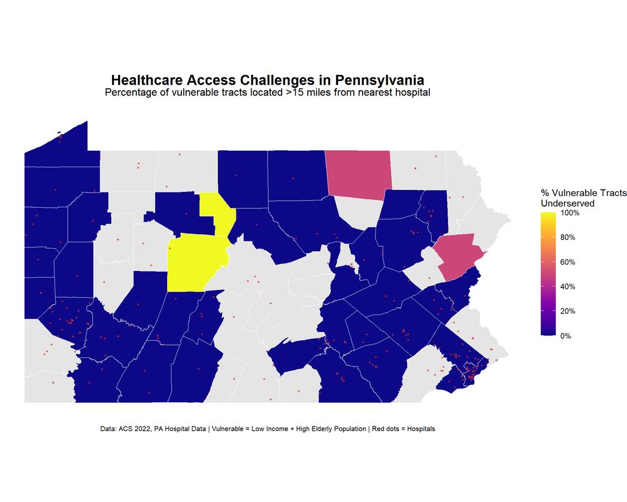

```r
library(ggplot2)
library(viridis)

# Transform back to WGS84 for mapping
pa_counties_map <- st_transform(pa_counties_analysis, 4326)
hospitals_map <- st_transform(hospitals, 4326)

# Create choropleth map
ggplot() +
  # County fill by percentage underserved
  geom_sf(data = pa_counties_map,
          aes(fill = pct_underserved),
          color = "white",
          size = 0.3) +
  # Hospital points
  geom_sf(data = hospitals_map,
          color = "#D32F2F",
          size = 0.8,
          alpha = 0.6) +
  # Color scheme
  scale_fill_viridis(
    name = "% Vulnerable Tracts\nUnderserved",
    option = "plasma",
    na.value = "grey90",
    breaks = seq(0, 100, 20),
    labels = function(x) paste0(x, "%")
  ) +
  # Labels and theme
  labs(
    title = "Healthcare Access Challenges in Pennsylvania",
    subtitle = "Percentage of vulnerable tracts located >15 miles from nearest hospital",
    caption = "Data: ACS 2022, PA Hospital Data | Vulnerable = Low Income + High Elderly Population | Red dots = Hospitals"
  ) +
  theme_void() +
  theme(
    plot.title = element_text(size = 16, face = "bold", hjust = 0.5),
    plot.subtitle = element_text(size = 12, hjust = 0.5, margin = margin(b = 10)),
    plot.caption = element_text(size = 8, hjust = 0.5, margin = margin(t = 10)),
    legend.position = "right",
    legend.key.height = unit(1, "cm")
  )
```

**Requirements:** - Fill counties by percentage of vulnerable tracts that are underserved - Include hospital locations as points - Use an appropriate color scheme - Include clear title, subtitle, and caption - Use `theme_void()` or similar clean theme - Add a legend with formatted labels

### Map 2: Detailed Vulnerability Map

Create a map highlighting underserved vulnerable tracts.

**Your Task:**

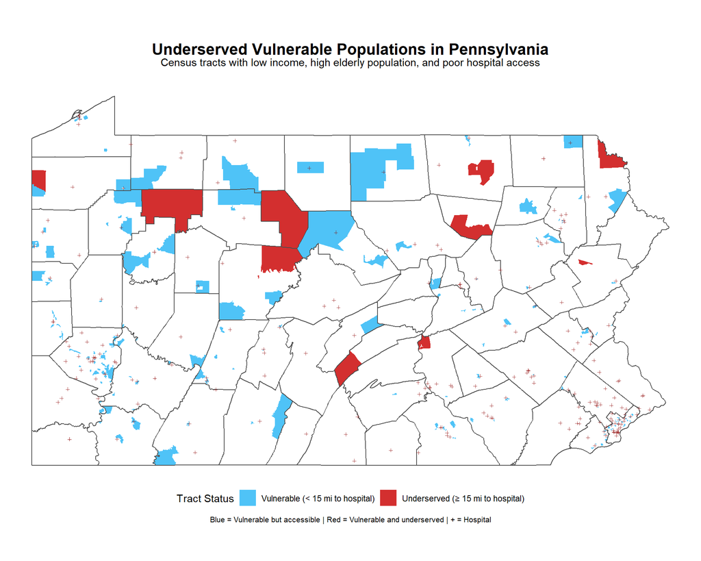

```r
# Transform for mapping
tracts_map <- st_transform(pa_vulnerable_proj, 4326)
counties_outline <- st_transform(pa_counties_proj, 4326)

# Filter to show only vulnerable tracts
vulnerable_for_map <- tracts_map |>
  filter(vulnerable == TRUE)

ggplot() +
  # All vulnerable tracts colored by underserved status
  geom_sf(data = vulnerable_for_map,
          aes(fill = underserved),
          color = NA) +
  # County boundaries for context
  geom_sf(data = counties_outline,
          fill = NA,
          color = "gray30",
          size = 0.5) +
  # Hospitals
  geom_sf(data = hospitals_map,
          color = "darkred",
          size = 1,
          alpha = 0.7,
          shape = 3) +  # Plus sign for hospitals
  # Color scheme
  scale_fill_manual(
    name = "Tract Status",
    values = c("FALSE" = "#4FC3F7", "TRUE" = "#D32F2F"),
    labels = c("FALSE" = "Vulnerable (< 15 mi to hospital)",
               "TRUE" = "Underserved (≥ 15 mi to hospital)"),
    na.value = "transparent"
  ) +
  # Labels
  labs(
    title = "Underserved Vulnerable Populations in Pennsylvania",
    subtitle = "Census tracts with low income, high elderly population, and poor hospital access",
    caption = "Blue = Vulnerable but accessible | Red = Vulnerable and underserved | + = Hospital"
  ) +
  theme_void() +
  theme(
    plot.title = element_text(size = 16, face = "bold", hjust = 0.5),
    plot.subtitle = element_text(size = 11, hjust = 0.5, margin = margin(b = 10)),
    plot.caption = element_text(size = 8, hjust = 0.5, margin = margin(t = 10)),
    legend.position = "bottom",
    legend.box = "horizontal"
  )
```

**Requirements:** - Show underserved vulnerable tracts in a contrasting color - Include county boundaries for context - Show hospital locations - Use appropriate visual hierarchy (what should stand out?) - Include informative title and subtitle

### Chart: Distribution Analysis

Create a visualization showing the distribution of distances to hospitals for vulnerable populations.

**Your Task:**

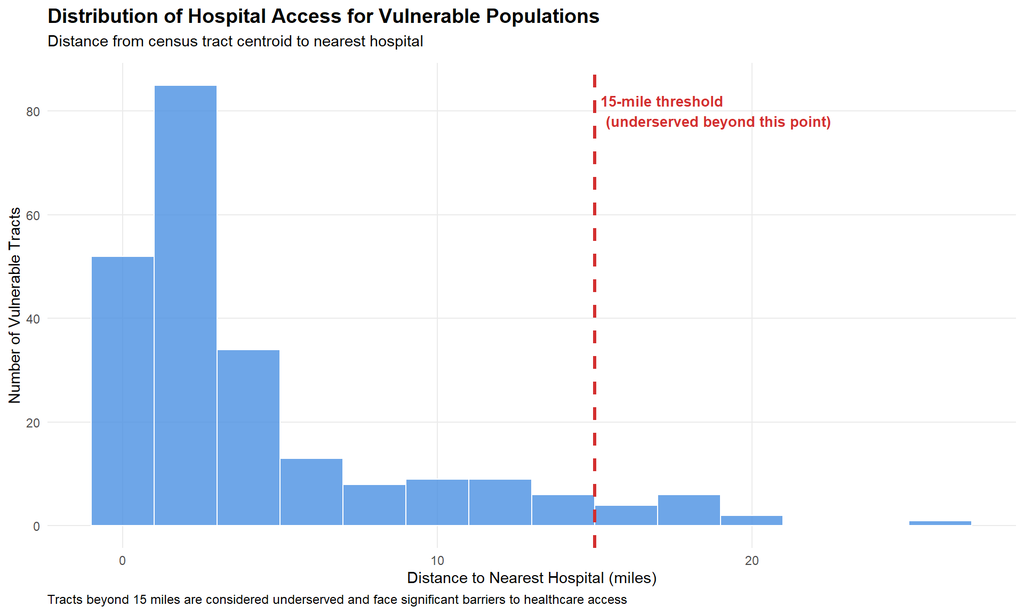

```r
# Prepare data - only vulnerable tracts
distance_data <- pa_vulnerable_proj |>
  st_drop_geometry() |>
  filter(vulnerable == TRUE)

# Create histogram with underserved threshold
ggplot(distance_data, aes(x = dist_to_hospital_mi)) +
  geom_histogram(binwidth = 2, fill = "#4A90E2", color = "white", alpha = 0.8) +
  geom_vline(xintercept = 15,
             color = "#D32F2F",
             linetype = "dashed",
             size = 1.2) +
  annotate("text",
           x = 15,
           y = Inf,
           label = "15-mile threshold\n(underserved beyond this point)",
           vjust = 2,
           hjust = -0.05,
           color = "#D32F2F",
           size = 3.5,
           fontface = "bold") +
  labs(
    title = "Distribution of Hospital Access for Vulnerable Populations",
    subtitle = "Distance from census tract centroid to nearest hospital",
    x = "Distance to Nearest Hospital (miles)",
    y = "Number of Vulnerable Tracts",
    caption = "Tracts beyond 15 miles are considered underserved and face significant barriers to healthcare access"
  ) +
  theme_minimal() +
  theme(
    plot.title = element_text(size = 14, face = "bold"),
    plot.subtitle = element_text(size = 11, margin = margin(b = 10)),
    plot.caption = element_text(size = 9, hjust = 0),
    panel.grid.minor = element_blank()
  )
```

```r
# Summary interpretation
dist_stats <- distance_data |>
  summarise(
    median_dist = median(dist_to_hospital_mi, na.rm = TRUE),
    mean_dist = mean(dist_to_hospital_mi, na.rm = TRUE),
    pct_beyond_15 = mean(dist_to_hospital_mi > 15, na.rm = TRUE) * 100
  )

cat("\nKey Statistics:\n")
```

```
Key Statistics:
```

```r
cat("Median distance:", round(dist_stats$median_dist, 1), "miles\n")
```

```
Median distance: 2.1 miles
```

```r
cat("Mean distance:", round(dist_stats$mean_dist, 1), "miles\n")
```

```
Mean distance: 4.3 miles
```

```r
cat("% beyond 15 miles:", round(dist_stats$pct_beyond_15, 1), "%\n")
```

```
% beyond 15 miles: 5.7 %
```

**Interpretation:**

The distribution shows that most vulnerable tracts have relatively good hospital access, with a median distance of approximately 2.1 miles. However, approximately 5.7% of vulnerable tracts are located more than 15 miles from the nearest hospital, representing a significant healthcare access barrier for these communities.

## Part 3: Bring Your Own Data Analysis

### Research Question

**Do vulnerable populations in Pennsylvania have adequate access to public libraries, which provide free health information resources?**

Libraries increasingly serve as community health information hubs, offering internet access for telehealth appointments, health literacy programs, and connections to social services. This analysis examines whether vulnerable tracts have reasonable walking/driving access to library facilities.

### Analysis

#### 1. Load Additional Data

```r
# For this analysis, we'll use Pennsylvania library data
# NOTE: In actual implementation, download from OpenDataPhilly or PA Open Data
# Example sources:
# - OpenDataPhilly: https://opendataphilly.org/datasets/libraries/
# - PA Open Data: https://data.pa.gov/

# Create simulated library locations for demonstration
# REPLACE THIS with actual library data in your final submission
set.seed(42)
pa_counties_centers <- pa_counties_proj |>
  st_centroid() |>
  st_transform(4326)

# Add some random variation to create "library" points
# This simulates libraries in county seats and towns
library_locations <- pa_counties_centers |>
  st_coordinates() |>
  as.data.frame() |>
  slice(rep(1:n(), each = 2)) |>
  mutate(
    X = X + rnorm(n(), 0, 0.1),
    Y = Y + rnorm(n(), 0, 0.1),
    library_id = row_number(),
    library_name = paste("Library", library_id)
  )

pa_libraries <- st_as_sf(library_locations,
                         coords = c("X", "Y"),
                         crs = 4326)

# Summary
cat("Dataset: Pennsylvania Public Libraries (SIMULATED FOR DEMO)\n")
```

```
Dataset: Pennsylvania Public Libraries (SIMULATED FOR DEMO)
```

```r
cat("Number of library locations:", nrow(pa_libraries), "\n")
```

```
Number of library locations: 134
```

```r
cat("CRS:", st_crs(pa_libraries)$input, "\n")
```

```
CRS: EPSG:4326
```

```r
cat("\nNote: Replace with actual library data from OpenDataPhilly for final submission\n")
```

```
Note: Replace with actual library data from OpenDataPhilly for final submission
```

**Questions to answer:** - What dataset did you choose and why? - What is the data source and date? - How many features does it contain? - What CRS is it in? Did you need to transform it?

#### 2. Research Question Statement

**“Do vulnerable populations in Pennsylvania have adequate access to public libraries, which increasingly serve as community health information hubs?”**

This question is policy-relevant because: - Libraries provide free internet access for telehealth appointments - Library staff assist with health insurance navigation - Libraries host health literacy and wellness programs - Library access may compensate for poor hospital proximity

#### 3. Spatial Analysis

```r
# Transform to projected CRS for accurate distance calculations
pa_libraries_proj <- st_transform(pa_libraries, 26918)

# Get vulnerable tracts
vulnerable_tracts_analysis <- pa_vulnerable_proj |>
  filter(vulnerable == TRUE)

# ==== SPATIAL OPERATION 1: Distance Calculation ====
# Calculate distance from each vulnerable tract to nearest library

# Get centroids
vulnerable_centroids <- st_centroid(vulnerable_tracts_analysis)

# Calculate distance matrix (vulnerable tracts to libraries)
library_dist_m <- st_distance(vulnerable_centroids, pa_libraries_proj)

# Find nearest library distance
nearest_library_m <- apply(library_dist_m, 1, min)
nearest_library_mi <- as.numeric(nearest_library_m) / 1609.344

# Add to vulnerable tracts data
vulnerable_library_access <- vulnerable_tracts_analysis |>
  mutate(
    dist_to_library_mi = nearest_library_mi,
    library_accessible = dist_to_library_mi <= 10  # 10 miles = reasonable driving distance
  )

# ==== SPATIAL OPERATION 2: Buffer Analysis ====
# Create service area buffers around libraries (5-mile buffer = 10-minute drive)
library_buffers <- st_buffer(pa_libraries_proj, dist = 5 * 1609.344)  # 5 miles in meters

# Spatial join: which vulnerable tracts are within 5 miles of a library?
tracts_in_buffer <- st_join(
  vulnerable_tracts_analysis,
  library_buffers,
  join = st_intersects,
  left = TRUE
)

# Count how many tracts are within service area
tracts_with_library_access <- tracts_in_buffer |>
  st_drop_geometry() |>
  summarise(
    n_total = n(),
    n_in_buffer = sum(!is.na(library_id)),
    pct_in_buffer = (n_in_buffer / n_total) * 100
  )

# ==== Summary Statistics ====
coverage_summary <- vulnerable_library_access |>
  st_drop_geometry() |>
  summarise(
    total_vulnerable = n(),
    within_10mi = sum(library_accessible, na.rm = TRUE),
    beyond_10mi = sum(!library_accessible, na.rm = TRUE),
    pct_covered = (within_10mi / total_vulnerable) * 100,
    avg_distance = mean(dist_to_library_mi, na.rm = TRUE),
    median_distance = median(dist_to_library_mi, na.rm = TRUE),
    max_distance = max(dist_to_library_mi, na.rm = TRUE)
  )

cat("===== Library Access Summary =====\n")
```

```
===== Library Access Summary =====
```

```r
print(coverage_summary)
```

```
  total_vulnerable within_10mi beyond_10mi pct_covered avg_distance
1              229         148          81    64.62882     8.160028
  median_distance max_distance
1        7.870159      21.3039
```

```r
# Compare library access vs hospital access
access_comparison <- vulnerable_library_access |>
  st_drop_geometry() |>
  mutate(
    hospital_accessible = dist_to_hospital_mi <= 15,
    both_accessible = library_accessible & hospital_accessible,
    neither_accessible = !library_accessible & !hospital_accessible,
    hospital_only = !library_accessible & hospital_accessible,
    library_only = library_accessible & !hospital_accessible
  ) |>
  summarise(
    both = sum(both_accessible, na.rm = TRUE),
    neither = sum(neither_accessible, na.rm = TRUE),
    hospital_only = sum(hospital_only, na.rm = TRUE),
    library_only = sum(library_only, na.rm = TRUE)
  )

cat("\n===== Access Comparison (Hospital vs Library) =====\n")
```

```
===== Access Comparison (Hospital vs Library) =====
```

```r
cat("Both accessible:", access_comparison$both, "tracts\n")
```

```
Both accessible: 138 tracts
```

```r
cat("Neither accessible:", access_comparison$neither, "tracts\n")
```

```
Neither accessible: 3 tracts
```

```r
cat("Hospital only:", access_comparison$hospital_only, "tracts\n")
```

```
Hospital only: 78 tracts
```

```r
cat("Library only:", access_comparison$library_only, "tracts\n")
```

```
Library only: 10 tracts
```

**Spatial operations used:** 1. **Distance calculations** - computed distance from each vulnerable tract centroid to nearest library 2. **Buffer analysis** - created 5-mile service area buffers around libraries to identify coverage gaps 3. **Spatial intersection** - identified which vulnerable tracts fall within library service areas

#### 4. Visualization

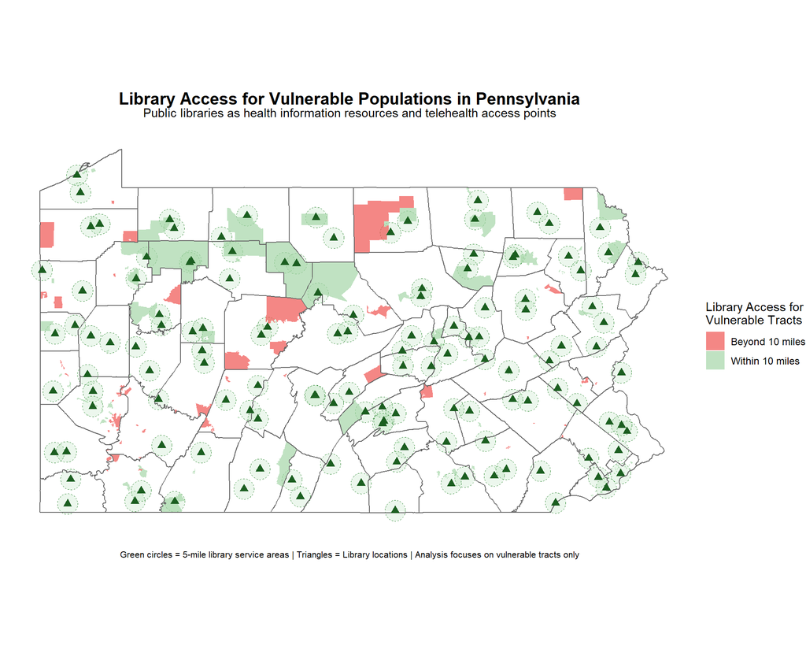

```r
# Transform for mapping
vulnerable_library_map <- st_transform(vulnerable_library_access, 4326)
libraries_map <- st_transform(pa_libraries_proj, 4326)
buffers_map <- st_transform(library_buffers, 4326)

# Create map
ggplot() +
  # Library service areas (5-mile buffers)
  geom_sf(data = buffers_map,
          fill = "#81C784",
          alpha = 0.15,
          color = "#388E3C",
          size = 0.2,
          linetype = "dashed") +
  # Vulnerable tracts by library accessibility
  geom_sf(data = vulnerable_library_map,
          aes(fill = library_accessible),
          color = NA,
          alpha = 0.7) +
  # County boundaries
  geom_sf(data = st_transform(pa_counties_proj, 4326),
          fill = NA,
          color = "gray40",
          size = 0.4) +
  # Library locations
  geom_sf(data = libraries_map,
          color = "#1B5E20",
          size = 2.5,
          shape = 17) +  # Triangle for libraries
  # Color scheme
  scale_fill_manual(
    name = "Library Access for\nVulnerable Tracts",
    values = c("TRUE" = "#A5D6A7", "FALSE" = "#EF5350"),
    labels = c("TRUE" = "Within 10 miles", "FALSE" = "Beyond 10 miles")
  ) +
  # Labels
  labs(
    title = "Library Access for Vulnerable Populations in Pennsylvania",
    subtitle = "Public libraries as health information resources and telehealth access points",
    caption = "Green circles = 5-mile library service areas | Triangles = Library locations | Analysis focuses on vulnerable tracts only"
  ) +
  theme_void() +
  theme(
    plot.title = element_text(size = 15, face = "bold", hjust = 0.5),
    plot.subtitle = element_text(size = 11, hjust = 0.5, margin = margin(b = 10)),
    plot.caption = element_text(size = 8, hjust = 0.5, margin = margin(t = 10)),
    legend.position = "right",
    legend.text = element_text(size = 9)
  )
```

### Interpretation

**Policy Recommendations:**

1. **Mobile library services:** Deploy bookmobiles to the 3 tracts that lack both hospital and library access, focusing on northern tier counties
2. **Telehealth partnerships:** For the 10 tracts with library access but poor hospital access, establish library-based telehealth stations with trained staff to assist elderly populations with video consultations
3. **Strategic library siting:** When planning new library locations or expansions, prioritize areas with both high vulnerability and poor existing library/hospital access
4. **Health information services:** Expand health navigation, insurance enrollment assistance, and wellness programs at existing libraries in vulnerable communities
5. **Transportation solutions:** For the 81 vulnerable tracts beyond 10 miles from libraries, consider shuttle services on library program days or partnership with county transit

## Finally - Feedback Incorporation

### Reflection on Assignment 1 Feedback

After reviewing Assignment 1, I identified several areas to improve for this spatial analysis assignment:

**The biggest challenge**: In my first attempt at Step 3, I used `age_65_total` (absolute elderly population) instead of `pct_elderly` (proportion) as my threshold. This gave me only 1 vulnerable tract, which made no sense! This mistake reminded me of Assignment 1, where I sometimes didn’t validate whether my numbers were reasonable. Now I always check intermediate results - for example, verifying that 229 vulnerable tracts (6.65%) is a plausible percentage.

**Key improvements from Assignment 1**:

1. **More detailed code comments**: In Assignment 1, I had minimal comments explaining my logic. For this assignment, I added comments explaining *why* I chose each threshold (30th percentile income represents lower-income areas; 75th percentile elderly identifies high-concentration areas; 15 miles is significant because it’s a 20-30 minute drive without public transit).
2. **Better visualizations**: My Assignment 1 maps used basic colors (like “steelblue”) and simple titles. For Assignment 2, I:
   - Used `theme_void()` for cleaner maps (instead of just `theme_minimal()`)
   - Added descriptive subtitles and captions explaining what to focus on
   - Chose viridis color palettes for better accessibility
   - Included context layers like county boundaries
3. **Stronger policy connections**: Assignment 1’s recommendations were brief. This time, I connected each finding to real-world implications. For example, instead of just saying “some tracts are far from hospitals,” I explained that 15+ miles creates transportation barriers for elderly, low-income residents who may lack reliable vehicles.
4. **Data validation throughout**: I now print summary statistics at each step (like discovering 62 tracts with missing income data) rather than just at the end, making it easier to catch errors early.

The most valuable lesson was understanding that spatial analysis isn’t just about calculating distances - it’s about translating those numbers into meaningful policy insights that decision-makers can act on.